```python
import pandas as pd
import numpy as np
import matplotlib.pyplot as plt
import seaborn as sns
%matplotlib inline
import warnings
warnings.filterwarnings('ignore')
```

# Important features:

```
   Target - the target is an ordinal variable indicating groups of income levels.
    1 = extreme poverty
    2 = moderate poverty
    3 = vulnerable households
    4 = non vulnerable households
idhogar - this is a unique identifier for each household. This can be used to create household-wide features, etc. All rows in a given household will have a matching value for this identifier.
parentesco1 - indicates if this person is the head of the household.
```

```python
df=pd.read_csv('train.csv')
```

- As test data provided is not containing target variable and it was used to check for kagale competetion so we ignore test data provided in zip file in our project and we simply train and test our model on train data.

```python
print(df.shape)
```

```
(9557, 143)
```

```python
df.info()
```

```
<class 'pandas.core.frame.DataFrame'>
RangeIndex: 9557 entries, 0 to 9556
Columns: 143 entries, Id to Target
dtypes: float64(8), int64(130), object(5)
memory usage: 10.4+ MB
```

- we came to know that our data contains 3types of variable. we need to connect object type of variable

```python
df.select_dtypes('object').head(5)
```

|  | Id | idhogar | dependency | edjefe | edjefa |
| --- | --- | --- | --- | --- | --- |
| 0 | ID_279628684 | 21eb7fcc1 | no | 10 | no |
| 1 | ID_f29eb3ddd | 0e5d7a658 | 8 | 12 | no |
| 2 | ID_68de51c94 | 2c7317ea8 | 8 | no | 11 |
| 3 | ID_d671db89c | 2b58d945f | yes | 11 | no |
| 4 | ID_d56d6f5f5 | 2b58d945f | yes | 11 | no |

```python
# Reshaping the mixed values for object
mapping_incorrections = {'yes': 1, 'no': 0}

# Reshaping the data based on replace the yes and no
for d in [df]:
    for col in ['dependency', 'edjefa', 'edjefe']:
        d[col] = d[col].replace(mapping_incorrections).astype(np.float64)
```

```python
df[['dependency', 'edjefa', 'edjefe']].dtypes
```

```
dependency    float64
edjefa        float64
edjefe        float64
dtype: object
```

```python
df.describe()
```

|  | v2a1 | hacdor | rooms | hacapo | v14a | refrig | v18q | v18q1 | r4h1 | r4h2 | ... | SQBescolari | SQBage | SQBhogar_total | SQBedjefe | SQBhogar_nin | SQBovercrowding | SQBdependency | SQBmeaned | agesq | Target |
| --- | --- | --- | --- | --- | --- | --- | --- | --- | --- | --- | --- | --- | --- | --- | --- | --- | --- | --- | --- | --- | --- |
| count | 2.697000e+03 | 9557.000000 | 9557.000000 | 9557.000000 | 9557.000000 | 9557.000000 | 9557.000000 | 2215.000000 | 9557.000000 | 9557.000000 | ... | 9557.000000 | 9557.000000 | 9557.000000 | 9557.000000 | 9557.000000 | 9557.000000 | 9557.000000 | 9552.000000 | 9557.000000 | 9557.000000 |
| mean | 1.652316e+05 | 0.038087 | 4.955530 | 0.023648 | 0.994768 | 0.957623 | 0.231767 | 1.404063 | 0.385895 | 1.559171 | ... | 74.222769 | 1643.774302 | 19.132887 | 53.500262 | 3.844826 | 3.249485 | 3.900409 | 102.588867 | 1643.774302 | 3.302292 |
| std | 1.504571e+05 | 0.191417 | 1.468381 | 0.151957 | 0.072145 | 0.201459 | 0.421983 | 0.763131 | 0.680779 | 1.036574 | ... | 76.777549 | 1741.197050 | 18.751395 | 78.445804 | 6.946296 | 4.129547 | 12.511831 | 93.516890 | 1741.197050 | 1.009565 |
| min | 0.000000e+00 | 0.000000 | 1.000000 | 0.000000 | 0.000000 | 0.000000 | 0.000000 | 1.000000 | 0.000000 | 0.000000 | ... | 0.000000 | 0.000000 | 1.000000 | 0.000000 | 0.000000 | 0.040000 | 0.000000 | 0.000000 | 0.000000 | 1.000000 |
| 25% | 8.000000e+04 | 0.000000 | 4.000000 | 0.000000 | 1.000000 | 1.000000 | 0.000000 | 1.000000 | 0.000000 | 1.000000 | ... | 16.000000 | 289.000000 | 9.000000 | 0.000000 | 0.000000 | 1.000000 | 0.111111 | 36.000000 | 289.000000 | 3.000000 |
| 50% | 1.300000e+05 | 0.000000 | 5.000000 | 0.000000 | 1.000000 | 1.000000 | 0.000000 | 1.000000 | 0.000000 | 1.000000 | ... | 36.000000 | 961.000000 | 16.000000 | 36.000000 | 1.000000 | 2.250000 | 0.444444 | 81.000000 | 961.000000 | 4.000000 |
| 75% | 2.000000e+05 | 0.000000 | 6.000000 | 0.000000 | 1.000000 | 1.000000 | 0.000000 | 2.000000 | 1.000000 | 2.000000 | ... | 121.000000 | 2601.000000 | 25.000000 | 81.000000 | 4.000000 | 4.000000 | 1.777778 | 134.560010 | 2601.000000 | 4.000000 |
| max | 2.353477e+06 | 1.000000 | 11.000000 | 1.000000 | 1.000000 | 1.000000 | 1.000000 | 6.000000 | 5.000000 | 8.000000 | ... | 441.000000 | 9409.000000 | 169.000000 | 441.000000 | 81.000000 | 36.000000 | 64.000000 | 1369.000000 | 9409.000000 | 4.000000 |

8 rows × 141 columns

```python
df.isnull().any().sum()
```

```
5
```

total 5 columns contains missing values there

```python
df['Target'].isnull().any()
```

```
False
```

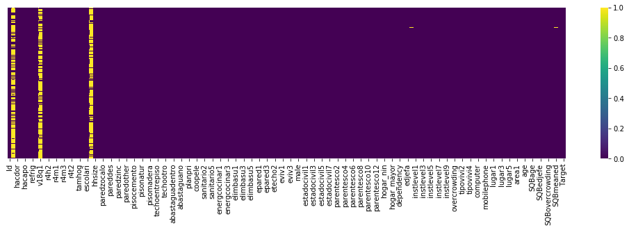

```python
plt.rcParams['figure.figsize'] = (18, 4)
sns.heatmap(df.isnull(),yticklabels=False,cmap='viridis')
```

```python
def get_dtypes(data, verbose=False):
    """Returns a list: numerical values, object-like columns"""

    numerics = ['int16', 'int32', 'int64', 'float16', 'float32', 'float64']
    numerics_cols = data.select_dtypes(include=numerics).columns
    object_cols = data.select_dtypes(include='object').columns
    if verbose:
        print('There are {0} numeric cols: {1}\nThere are {2} object cols: {3}\nThere are total cols: {4}'.format
              (len(numerics_cols),numerics_cols, len(object_cols), object_cols, len(data.columns)))
    return [numerics_cols, object_cols]
```

```python
def get_missing_values(data, cols):
    """Returns a dataframe with missing values (in absolute and percentage format)"""

    missing_percent = data[cols].apply(lambda x: sum(x.isnull())/len(x), axis=0).sort_values(ascending=False)
    missing_abs = data[cols].apply(lambda x: sum(x.isnull()), axis=0).sort_values(ascending=False)
    b = pd.DataFrame({'Missing': missing_abs, 'Percent': missing_percent})

    # Removing zero values
    b = b.loc[~(b==0).all(axis=1)]
    return b
```

```python
num_cols, obj_cols = get_dtypes(df, verbose=False)
```

```python
get_missing_values(df, num_cols)
```

|  | Missing | Percent |
| --- | --- | --- |
| rez_esc | 7928 | 0.829549 |
| v18q1 | 7342 | 0.768233 |
| v2a1 | 6860 | 0.717798 |
| meaneduc | 5 | 0.000523 |
| SQBmeaned | 5 | 0.000523 |

# We are having 5 columns where we are getting missing values

- Notes:

  Notice that all values that are 0 in the v18q column (binary if a person owns a tablet), for every value that v18q1 is null,  
  it is also label as 0 means if they dont have a tablet then the tablet count will be zero

```python
# Filling in the missing value
df['v18q1'] = df['v18q1'].fillna(0)
```

- If the house is of own or they are paying loan then there must not be any rent for those people so we are filling all "v2a1" null values to be 0

```python
df['v2a1'] = df['v2a1'].fillna(0)
```

Notes:

```
You cannot be "years" in school if you are not in school.
Thus, we can make this value 0 if you are younger than 7 or older than 19
```

```python
print(df['rez_esc'].value_counts())
```

```
0.0    1211
1.0     227
2.0      98
3.0      55
4.0      29
5.0       9
Name: rez_esc, dtype: int64
```

```python
# If individual is over 19 or younger than 7 and missing years behind, set it to 0
df.loc[((df['age'] > 19) | (df['age'] < 7)) & (df['rez_esc'].isnull()), 'rez_esc'] = 0
```

```python
df['Target'].unique()
```

```python
df['rez_esc'].isnull().sum()
```

we are considering all the missing values in df['rez_esc'] as zero

```python
df['rez_esc'] = df['rez_esc'].fillna(0)
```

```python
df['rez_esc'].isnull().sum()
```

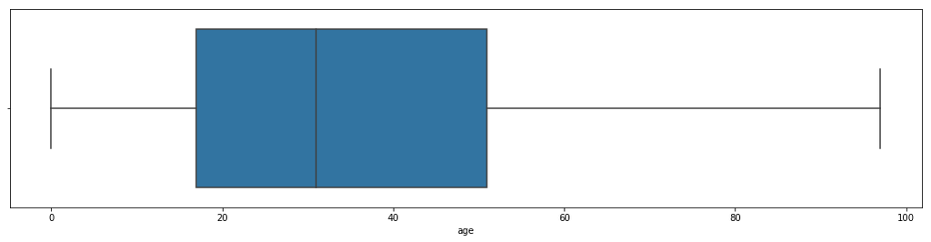

```python
sns.boxplot(df['age'])
```

```python
df=df.dropna()
```

Checking for Distribution and relations of Dataset

```python
get_missing_values(df, num_cols)
```

|  | Missing | Percent |
| --- | --- | --- |

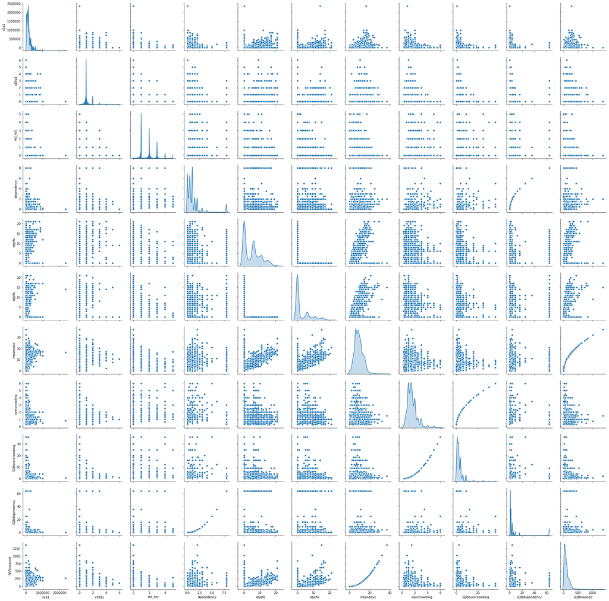

```python
p=sns.pairplot(df.select_dtypes('float64'),diag_kind='kde')
```

```python
# Mapping the values of floating columns
from collections import OrderedDict

# Color mapping
colors = OrderedDict({1: 'red', 2: 'orange', 3: 'blue', 4: 'green'})
poverty_mapping = OrderedDict({1: 'extreme', 2: 'moderate', 3: 'vulnerable', 4: 'non vulnerable'})
```

[output not shown]

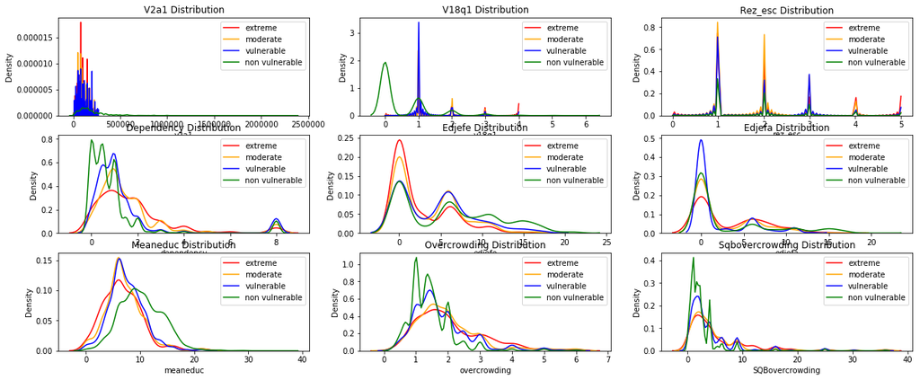

```python
plt.figure(figsize=(20, 8))

# Iterate through the float columns
for i, col in enumerate(df.select_dtypes('float')):
    ax = plt.subplot(3, 3, i + 1)

    # Iterate through the poverty levels
    for poverty_level, color in colors.items():

        # Plot each poverty level as a separate line
        sns.kdeplot(df.loc[df['Target'] == poverty_level, col].dropna(),
                    ax=ax, color=color, label=poverty_mapping[poverty_level])

    plt.title(f'{col.capitalize()} Distribution'); plt.xlabel(f'{col}'); plt.ylabel('Density')

plt.subplots_adjust(top=2)
```

NOTES: From above plot we came to know that all SQB columns are just a squares of available features and both are highly corelated this will doesn't add any value to our analysis. so we are dropping these unnecessary columns

```python
# Square features in our dataset
sqr_ = ['SQBescolari', 'SQBage', 'SQBhogar_total', 'SQBedjefe', 'SQBhogar_nin',
        'SQBovercrowding', 'SQBdependency', 'SQBmeaned', 'agesq']
```

```python
# Removing square features as it does not add anything to our dataset
df =df.drop(sqr_, axis=1)
df.shape
```

## Just check poverty level counts

```python
# SETTING UP THE TARGET VARIABLES
TARGET_AXIS_LABELS = ('non-vunerable hh', 'moderate pov', 'vunerable hh', 'extreme pov')
```

[figure not shown]

```python
# Understanding the distribution of the target variable
countplot=sns.countplot(df.Target)
countplot.set_xticklabels(labels=TARGET_AXIS_LABELS, rotation=40)
plt.title("Poverty Level")
```

```python
# Potential error: the household does not have a head leader
hh_head = df.groupby('idhogar')['parentesco1'].sum()

# Find households without a head leader
hh_no_head = df.loc[df['idhogar'].isin(hh_head[hh_head == 0].index), :]
hh_no_head['idhogar'].nunique()
```

```
19
```

```python
df.groupby(['idhogar','parentesco1'])['Target'].count().head()
```

```
idhogar    parentesco1
001ff74ca  0              1
           1              1
003123ec2  0              3
           1              1
004616164  0              1
Name: Target, dtype: int64
```

```python
import pandas as pd
from sklearn.model_selection import train_test_split
from sklearn.neighbors import KNeighborsClassifier
from sklearn.preprocessing import StandardScaler
from sklearn.metrics import confusion_matrix
from sklearn.metrics import f1_score
from sklearn.ensemble import RandomForestClassifier,AdaBoostClassifier,GradientBoostingClassifier
```

```python
X=df.drop(['Id','idhogar','Target'],axis=1)
y=df['Target']
X_train, X_test, y_train, y_test = train_test_split(X, y, test_size=0.20,random_state=42)
sc=StandardScaler()
scaledX_train = sc.fit_transform(X_train)
scaledX_test = sc.transform(X_test)
```

```python
from sklearn.neighbors import KNeighborsClassifier
knn = KNeighborsClassifier(n_neighbors=3)
knn.fit(scaledX_train,y_train)
pred = knn.predict(scaledX_test)
```

```python
### GET both classification report and confusion matrix
from sklearn.metrics import classification_report,confusion_matrix,accuracy_score
print(accuracy_score(pred,y_test))
print(confusion_matrix(y_test,pred))
print(classification_report(y_test,pred))
```

```
0.8110749185667753
[[  99    9    6   28]
 [  18  222    6   79]
 [  15   39  129   54]
 [  23   48   23 1044]]
              precision    recall  f1-score   support

           1       0.64      0.70      0.67       142
           2       0.70      0.68      0.69       325
           3       0.79      0.54      0.64       237
           4       0.87      0.92      0.89      1138

   micro avg       0.81      0.81      0.81      1842
   macro avg       0.75      0.71      0.72      1842
weighted avg       0.81      0.81      0.81      1842
```

```python
rf = RandomForestClassifier(n_estimators=21,random_state=42)
rf.fit(scaledX_train,y_train)

predicted = rf.predict(scaledX_test)
predtrain = rf.predict(scaledX_train)
```

```python
accuracy_score(predtrain,y_train)
```

```
0.9993211133740665
```

```python
print(accuracy_score(predicted,y_test))
print(confusion_matrix(y_test,predicted))
print(classification_report(y_test,predicted))
```

```
0.9180238870792616
[[ 108   11    1   22]
 [   2  274    4   45]
 [   0   18  175   44]
 [   0    3    1 1134]]
              precision    recall  f1-score   support

           1       0.98      0.76      0.86       142
           2       0.90      0.84      0.87       325
           3       0.97      0.74      0.84       237
           4       0.91      1.00      0.95      1138

   micro avg       0.92      0.92      0.92      1842
   macro avg       0.94      0.83      0.88      1842
weighted avg       0.92      0.92      0.92      1842
```

## All our F1_score for random forest are more than 80% this is good for our model

```python
features = list(X_train.columns)
# Feature importances into a dataframe
feature_importances = pd.DataFrame({'feature': features, 'importance': rf.feature_importances_})
feature_importances.sort_values(by="importance", ascending=False).head(5)
```

[output not shown]

```python
rftrain=[]
rftest=[]

for j in range(50):
    X_train, X_test, y_train, y_test = train_test_split(X, y, test_size=0.20,random_state=j)
    sc=StandardScaler()
    scaledX_train = sc.fit_transform(X_train)
    scaledX_test = sc.transform(X_test)
    rf = RandomForestClassifier(n_estimators=22)
    rf.fit(scaledX_train,y_train)

    rftrain.append(rf.score(scaledX_train,y_train))
    rftest.append(rf.score(scaledX_test,y_test))
print("Compute RF accuracy on the training set")
print(np.mean(rftrain))
print("Compute RF accuracy on the testing set")
print(np.mean(rftest))
```

```
Compute RF accuracy on the training set
0.9995655125594025
Compute RF accuracy on the testing set
0.9117698154180238
```

## Iterative acuuracy for Random forest we get upto 92% now we will verify cross validation score

```python
from sklearn.model_selection import cross_val_score
scores = cross_val_score(rf, scaledX_train,y_train, cv=10)
scores
```

```
array([0.90663058, 0.89837398, 0.91044776, 0.89673913, 0.88586957,
       0.89130435, 0.91711957, 0.9048913 , 0.86684783, 0.9170068 ])
```

```python
print("Accuracy mean score with the 95 percent confidence interval: %0.2f (+/- %0.2f)" % (scores.mean(), scores.std() * 2))
```

```
Accuracy mean score with the 95 percent confidence interval: 0.90 (+/- 0.03)
```